# Praktikum 6 Anreg

# Library

```r
library(readxl) # untuk membaca data
library(GGally) # untuk menghasilkan matriks hubungan antarpeubah
library(corrplot) # untuk menghasilkan matriks korelasi
library(dplyr) # untuk manipulasi data
library(car) # untuk memeriksa multikolinearitas
library(stargazer) # untuk menampilkan hasil perbandingan regresi
library(lmtest) # untuk uji kehomogenan ragam sisaan dan saling bebas
library(olsrr) # untuk pemeriksaan amatan tidak biasa
```

Data

```r
dt <- read_xlsx("C:\\Users\\Lenovo\\Downloads\\SEM 4\\ANREG\\data anreg\\DATA Persentase Pekerja Anak (usia 10-17 tahun) Menurut Provinsi, 2023.xlsx")
dt # menampilkan data
```

```
## # A tibble: 38 × 7
##    Provinsi               PPA     GK  PDRB   TPT   RLS  TPPT
##    <chr>                <dbl>  <dbl> <dbl> <dbl> <dbl> <dbl>
##  1 ACEH                  1.03 627534  4.23  6.03  9.55  97.4
##  2 SUMATERA UTARA        3.97 602999  5.01  5.89  9.82  96.0
##  3 SUMATERA BARAT        2.68 667925  4.62  5.94  9.28  96.7
##  4 RIAU                  2.22 658611  4.21  4.23  9.32  95.0
##  5 JAMBI                 1.94 599688  4.67  4.53  8.81  96.4
##  6 SUMATERA SELATAN      2.33 520754  5.08  4.11  8.5   98.2
##  7 BENGKULU              1.88 637142  4.28  3.42  9.03  98.8
##  8 LAMPUNG               2.49 559011  4.55  4.23  8.29  95.9
##  9 KEP. BANGKA BELITUNG  3.04 874204  4.38  4.56  8.25  96.5
## 10 KEP. RIAU             1.99 742526  5.16  6.8  10.4   96.6
## # ℹ 28 more rows
```

```r
str(dt) # menampilkan tipe data setiap peubah
```

```
## tibble [38 × 7] (S3: tbl_df/tbl/data.frame)
##  $ Provinsi: chr [1:38] "ACEH" "SUMATERA UTARA" "SUMATERA BARAT" "RIAU" ...
##  $ PPA     : num [1:38] 1.03 3.97 2.68 2.22 1.94 2.33 1.88 2.49 3.04 1.99 ...
##  $ GK      : num [1:38] 627534 602999 667925 658611 599688 ...
##  $ PDRB    : num [1:38] 4.23 5.01 4.62 4.21 4.67 5.08 4.28 4.55 4.38 5.16 ...
##  $ TPT     : num [1:38] 6.03 5.89 5.94 4.23 4.53 4.11 3.42 4.23 4.56 6.8 ...
##  $ RLS     : num [1:38] 9.55 9.82 9.28 9.32 8.81 ...
##  $ TPPT    : num [1:38] 97.4 96 96.7 95 96.4 ...
```

```r
summary(dt) # menampilkan ringkasan data
```

```
##    Provinsi              PPA              GK              PDRB
##  Length:38          Min.   :0.000   Min.   :     0   Min.   : 0.000
##  Class :character   1st Qu.:1.802   1st Qu.:481992   1st Qu.: 4.242
##  Mode  :character   Median :2.270   Median :566491   Median : 4.825
##                     Mean   :2.521   Mean   :534559   Mean   : 4.825
##                     3rd Qu.:3.853   3rd Qu.:653244   3rd Qu.: 5.140
##                     Max.   :5.610   Max.   :874204   Max.   :20.490
##       TPT             RLS              TPPT
##  Min.   :0.000   Min.   : 0.000   Min.   : 0.00
##  1st Qu.:3.080   1st Qu.: 8.033   1st Qu.:94.12
##  Median :4.270   Median : 8.785   Median :95.62
##  Mean   :4.128   Mean   : 7.988   Mean   :84.95
##  3rd Qu.:5.362   3rd Qu.: 9.335   3rd Qu.:96.53
##  Max.   :7.520   Max.   :11.450   Max.   :99.86
```

Data yang digunakan adalah data dari 38 provinsi di Indonesia pada Tahun 2023 dengan 1 peubah respon yaitu Persentase Pekerja Anak (PPA) dan 5 peubah penjelas yang semuanya merupakan peubah kuantitatif. Peubah tersebut adalah Garis Kemiskinan (GK), Produk Domestik Regional Bruto (PDRB), Tingkat Pengangguran Terbuka (TPT), Rata-rata Lama Sekolah (RLS), dan Tingkat partisipasi dalam pembelajaran yang teroganisir (TPPT). Untuk mempermudah dalam komputasi, karena peubah provinsi tidak digunakan, maka dapat dihapus. Pada praktikum kali ini akan dilakukan satu pemodelan, yakni model dengan seluruh peubah kuantitatif.

```r
dt <- select(dt, -Provinsi)
```

# Eksplorasi Data

## Peubah Respon

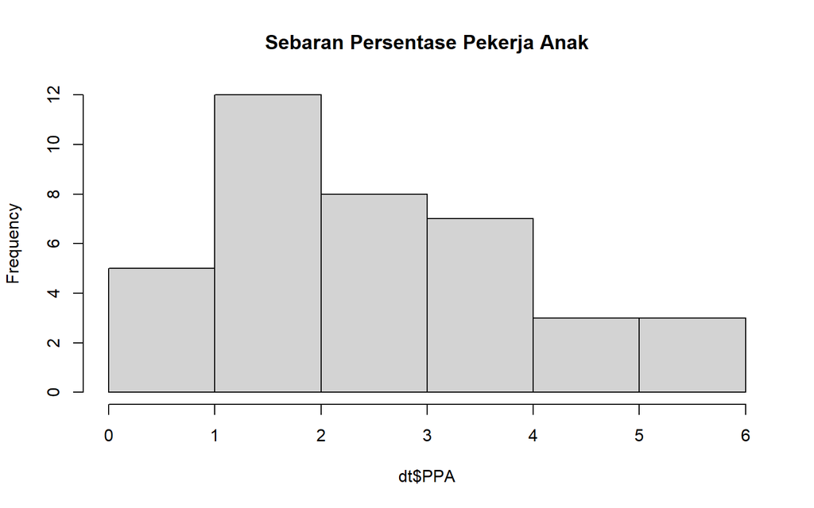

```r
hist(dt$PPA, main = "Sebaran Persentase Pekerja Anak")
```

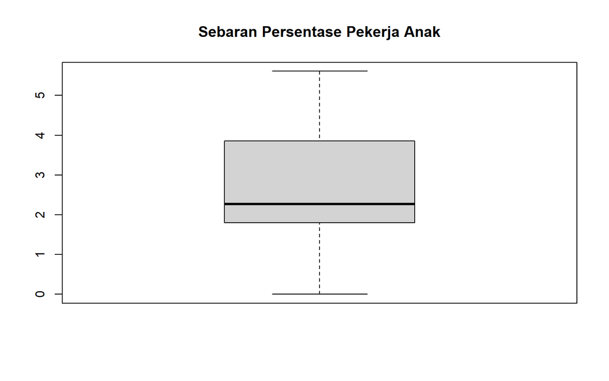

```r
boxplot(dt$PPA, main = "Sebaran Persentase Pekerja Anak")
```

## Peubah Pennjelas vs Peubah Respon

### GK

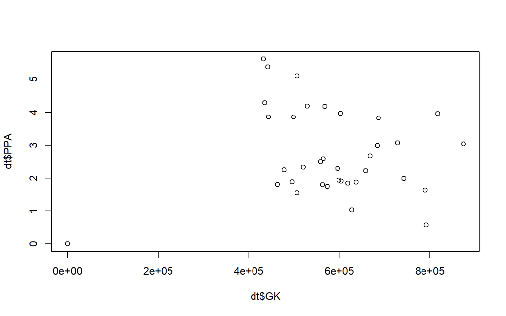

```r
plot(dt$GK, dt$PPA)
```

Hubungan antara peubah GK dan PPA cenderung tidak linear, ada satu amatan dengan nilai X jauh dari amatan lainnya

### PDRB

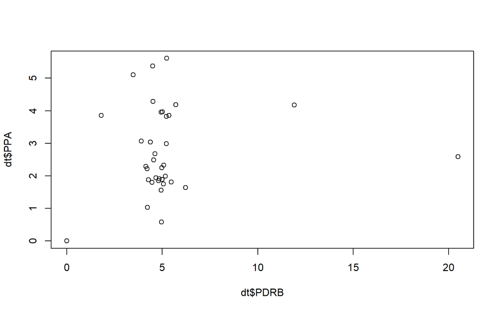

```r
plot(dt$PDRB, dt$PPA)
```

### TPT

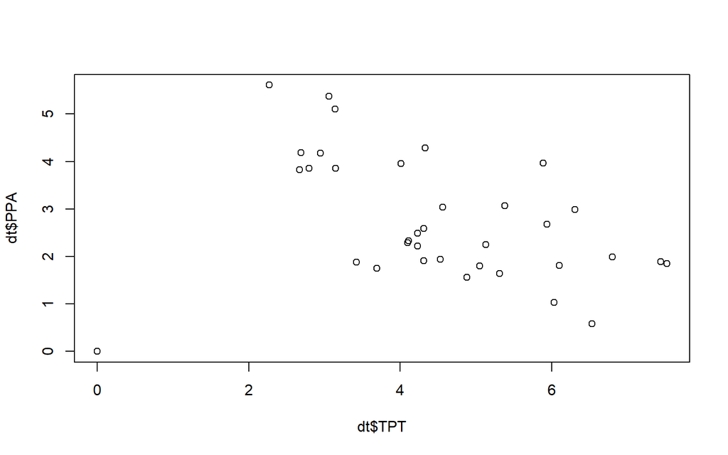

```r
plot(dt$TPT, dt$PPA)
```

Hubungan linearitas tampak antara peubah TPT dan PPA yang cenderung negatif lemah, ada satu amatan dengan nilai X jauh dari amatan lainnya.

### RLS

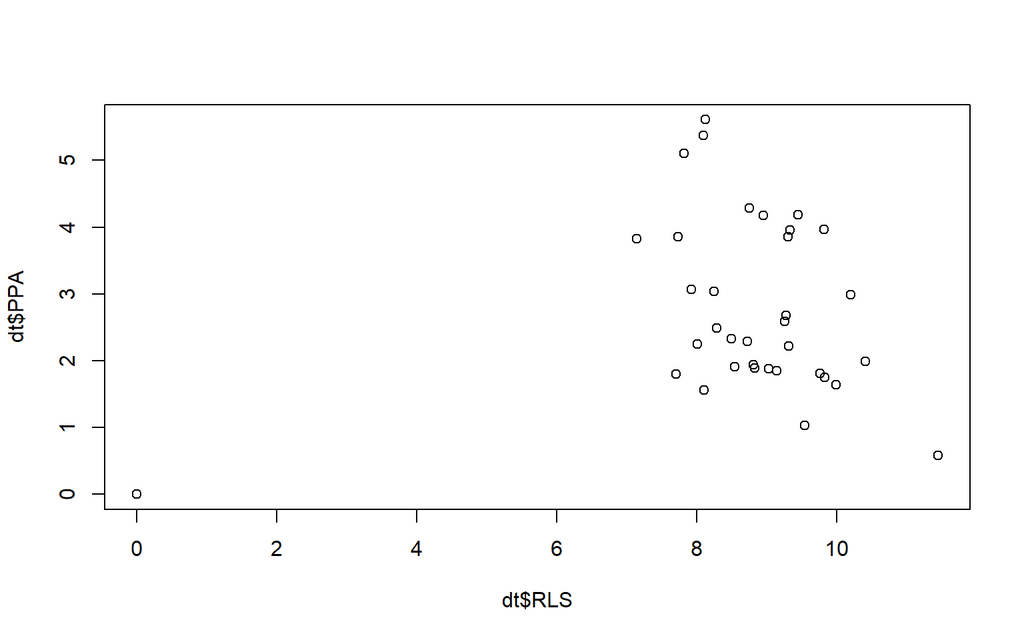

```r
plot(dt$RLS, dt$PPA)
```

Hubungan antara peubah RLS dan PPA cenderung tidak linear, ada satu amatan dengan nilai X jauh dari amatan lainnya.

# TPPT

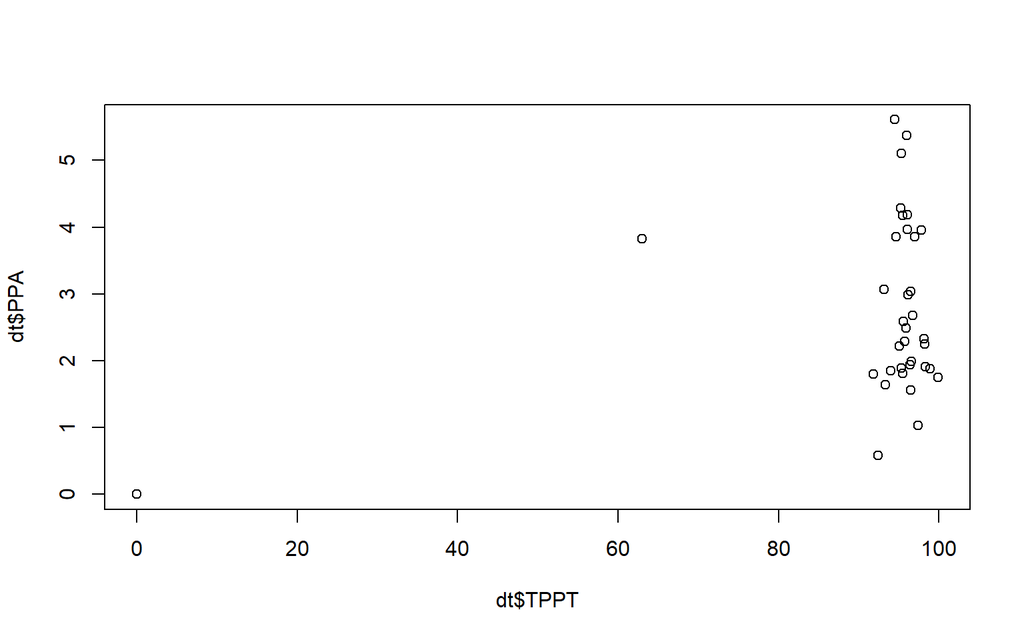

```r
plot(dt$TPPT, dt$PPA)
```

Hubungan antara peubah TPPT dan PPA cenderung tidak linear, ada satu amatan dengan nilai X jauh dari amatan lainnya.

## Korelasi

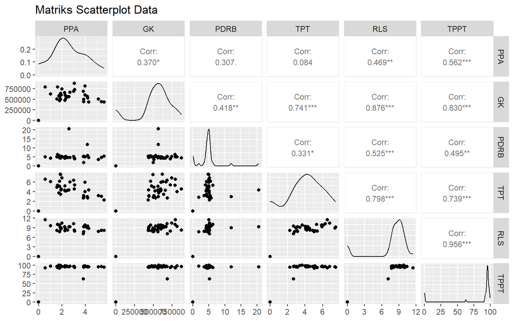

```r
ggpairs(dt,
        upper = list(continuous = wrap('cor', size = 3)),
        title = "Matriks Scatterplot Data")
```

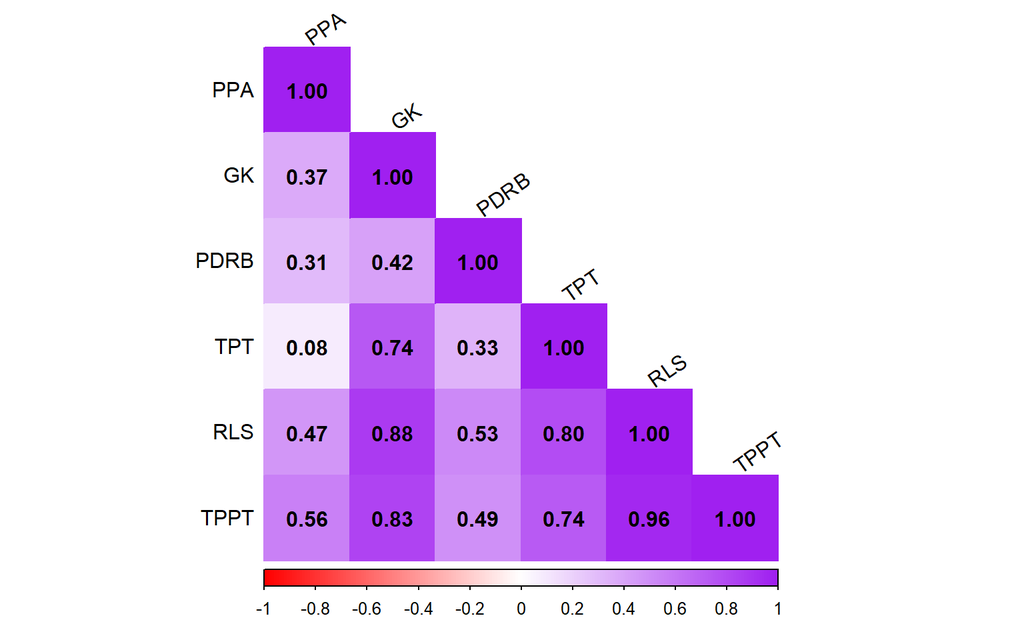

```r
cor_matrix <- cor(dt, use = "complete.obs")

corrplot(cor_matrix, method = "color", type = "lower",
         col = colorRampPalette(c("red", "white", "purple"))(200),
         addCoef.col = "black", tl.col = "black", tl.srt = 35)
```

Selain itu, terdapat banyak korelasi tinggi antar peubah penjelas, yang lebih dari 0.5. Beberapa di antaranya adalah: 1. TPT dan GK memiliki korelasi 0.741. 2. RLS dengan GK dan TPT masing-masing sebesar 0.876 dan 0.798. 3. TPPT dengan GK, TPT, dan RLS masing-masing sebesar 0.830, 0.739, dan 0.956.

Korelasi yang tinggi ini mengindikasikan adanya potensi multikolinearitas, yang dapat mempengaruhi keakuratan model yang akan dibentuk.

# Pemodelan

```r
model1 = lm(formula = PPA ~ ., data = dt)
summary(model1)
```

```
##
## Call:
## lm(formula = PPA ~ ., data = dt)
##
## Residuals:
##     Min      1Q  Median      3Q     Max
## -1.8169 -0.7553 -0.1948  0.6742  1.8128
##
## Coefficients:
##               Estimate Std. Error t value Pr(>|t|)
## (Intercept)  1.948e-01  5.209e-01   0.374  0.71084
## GK          -7.649e-08  1.686e-06  -0.045  0.96409
## PDRB         2.163e-03  6.268e-02   0.035  0.97269
## TPT         -5.457e-01  1.516e-01  -3.599  0.00106 **
## RLS         -6.756e-05  2.615e-01   0.000  0.99980
## TPPT         5.427e-02  1.985e-02   2.734  0.01011 *
## ---
## Signif. codes:  0 '***' 0.001 '**' 0.01 '*' 0.05 '.' 0.1 ' ' 1
##
## Residual standard error: 1.055 on 32 degrees of freedom
## Multiple R-squared:  0.5579, Adjusted R-squared:  0.4888
## F-statistic: 8.075 on 5 and 32 DF,  p-value: 5.131e-05
```

Pada ringkasan model ini dapat dilihat bahwa secara simultan minimal terdapat satu peubah penjelas yang berpengaruh signifikan terhadap PPM, ditunjukkan oleh nilai F-statistik sebesar 8,075 dengan p-value 5,131×10⁻⁵. Hal tersebut selaras karena terdapat dugaan parameter yang signifikan pada taraf nyata 5%, yaitu peubah TPT dan TPPT. Sementara itu, peubah GK, PDRB, dan RLS tidak signifikan secara parsial. Selanjutnya diperlukan pengujian asumsi pada model, dimulai dengan pemeriksaan multikolinearitas dilanjutkan dengan diagnosis sisaan.

# Pemeriksaan Multikolinearitas

## Perubahan Peubah

```r
mod1 <- lm(PPA ~ ., dt[1:2])
mod2 <- lm(PPA ~ ., dt[1:3])
mod3 <- lm(PPA ~ ., dt[1:4])
mod4 <- lm(PPA ~ ., dt[1:5])
mod5 <- lm(PPA ~ ., dt)

stargazer(mod1, mod2, mod3, mod4, mod5,
          type = "text", single.row = TRUE)
```

```
##
## ==============================================================================================================================
##                                                                Dependent variable:
##                     ----------------------------------------------------------------------------------------------------------
##                                                                        PPA
##                             (1)                  (2)                  (3)                   (4)                   (5)
## ------------------------------------------------------------------------------------------------------------------------------
## GK                  0.00000** (0.00000)   0.00000* (0.00000)  0.00000** (0.00000)   -0.00000 (0.00000)    -0.00000 (0.00000)
## PDRB                                        0.082 (0.076)        0.087 (0.073)        -0.008 (0.068)         0.002 (0.063)
## TPT                                                             -0.325* (0.166)      -0.603*** (0.164)     -0.546*** (0.152)
## RLS                                                                                  0.583*** (0.165)       -0.0001 (0.262)
## TPPT                                                                                                        0.054** (0.020)
## Constant               1.170* (0.608)       1.055* (0.616)      1.221** (0.598)        0.514 (0.555)         0.195 (0.521)
## ------------------------------------------------------------------------------------------------------------------------------
## Observations                 38                   38                   38                   38                    38
## R2                         0.137                0.165                0.249                 0.455                 0.558
## Adjusted R2                0.113                0.118                0.183                 0.388                 0.489
## Residual Std. Error   1.389 (df = 36)      1.386 (df = 35)      1.333 (df = 34)       1.154 (df = 33)       1.055 (df = 32)
## F Statistic         5.724** (df = 1; 36) 3.463** (df = 2; 35) 3.765** (df = 3; 34) 6.876*** (df = 4; 33) 8.075*** (df = 5; 32)
## ==============================================================================================================================
## Note:                                                                                              *p<0.1; **p<0.05; ***p<0.01
```

Terdapat perubahan tanda dugaan parameter pada peubah RLS dan PDRB ketika peubah lain ditambahkan ke dalam model. Pada peubah PDRB, tanda koefisien berubah dari positif menjadi negatif saat RLS dimasukkan pada model (4), kemudian kembali positif pada model (5). Pada peubah RLS, koefisien bernilai 0,583 pada model (4) namun berubah drastis menjadi −0,0001 setelah TPPT ditambahkan. Perubahan yang tidak konsisten ini mengindikasikan adanya permasalahan multikolinearitas dalam model.

## Perubahan Banyak Data

```r
mod5_1 <- lm(PPA ~ ., dt[1:15,])
stargazer(summary(mod5)$coefficients, summary(mod5_1)$coefficients,
          type = "text",
          font.size = "small")
```

```
##
## ===================================================
##             Estimate Std. Error t value Pr(> | t| )
## ---------------------------------------------------
## (Intercept)  0.195     0.521     0.374     0.711
## GK          -0.00000  0.00000   -0.045     0.964
## PDRB         0.002     0.063     0.035     0.973
## TPT          -0.546    0.152    -3.599     0.001
## RLS         -0.0001    0.262    -0.0003    1.000
## TPPT         0.054     0.020     2.734     0.010
## ---------------------------------------------------
##
## ===================================================
##             Estimate Std. Error t value Pr(> | t| )
## ---------------------------------------------------
## (Intercept)  -1.859    18.119   -0.103     0.921
## GK          0.00000   0.00000    0.936     0.374
## PDRB         0.569     0.860     0.662     0.525
## TPT          0.006     0.266     0.024     0.981
## RLS          -0.467    0.336    -1.389     0.198
## TPPT         0.040     0.175     0.229     0.824
## ---------------------------------------------------
```

Terdapat dugaan parameter yang mengalami perubahan besar ketika jumlah amatan berbeda, mengindikasi model bermasalah.

## Akar Ciri

```r
x <- dt[-1]
r <- cor(x)
(ev <- eigen(r)$values)
```

```
## [1] 3.76221705 0.73902751 0.28462092 0.17984815 0.03428637
```

```r
# Simultan
if ((max(ev) / min(ev)) <= 100) {
  cat("Tidak ada multikolinearitas\n")
} else if ((max(ev) / min(ev)) > 100 & (max(ev) / min(ev)) <= 1000) {
  cat("Ada multikolinearitas yang lemah\n")
} else {
  cat("Ada multikolinearitas yang kuat\n")
}
```

```
## Ada multikolinearitas yang lemah
```

```r
# Parsial
if (all((max(ev) / ev) <= 1000)) {
  cat("Tidak ada multikolinearitas\n")
} else {
  cat("Ada multikolinearitas pada peubah penjelas ke:", which((max(ev) / ev) > 1000), "\n")
}
```

```
## Tidak ada multikolinearitas
```

## Nilai VIF

```r
vif(model1)
```

```
##        GK      PDRB       TPT       RLS      TPPT
##  4.414648  1.437577  2.947382 19.224186 11.834941
```

Hasil pemeriksaan dengan akar ciri menyatakan ada multikolinearitas pada model karena nilai $k>100$ secara simultan walaupun lemah. Nilai VIF juga menunjukkan ada peubah yang VIF nya lebih dari 10 yaitu pada peubah penjelas RLS dan TPPT. Pada analisis kali ini, penanganan dilakukan dengan menghapus peubah bernilai VIF tinggi yaitu RLS dan TPPT.

# Pemodelan Penyisihan Peubah

```r
model2 <- lm(PPA ~ GK + PDRB + TPT, data = dt)
summary(model2)
```

```
##
## Call:
## lm(formula = PPA ~ GK + PDRB + TPT, data = dt)
##
## Residuals:
##     Min      1Q  Median      3Q     Max
## -2.2450 -1.0316 -0.1187  0.5223  2.9142
##
## Coefficients:
##               Estimate Std. Error t value Pr(>|t|)
## (Intercept)  1.221e+00  5.984e-01   2.040   0.0492 *
## GK           4.156e-06  1.570e-06   2.648   0.0122 *
## PDRB         8.686e-02  7.280e-02   1.193   0.2410
## TPT         -3.248e-01  1.663e-01  -1.953   0.0591 .
## ---
## Signif. codes:  0 '***' 0.001 '**' 0.01 '*' 0.05 '.' 0.1 ' ' 1
##
## Residual standard error: 1.333 on 34 degrees of freedom
## Multiple R-squared:  0.2494, Adjusted R-squared:  0.1831
## F-statistic: 3.765 on 3 and 34 DF,  p-value: 0.01951
```

Persamaan yang terbentuk adalah

$$\hat{PPA}=1.2210+0.0000042GK+0.0869PDRB-0.3248TPT$$

## Nilai VIF

```r
vif(model2)
```

```
##       GK     PDRB      TPT
## 2.395845 1.213453 2.219953
```

Model hasil reduksi peubah menunjukkan bahwa nilai VIF < 10 sehingga dinyatakan tidak terjadi multikolinearitas. Namun masih ada peubah yang mengalami perubahan tanda arah korelasi. Artinya ada permasalahan lain yang mungkin belum tertangani, perlu dilakuan uji asumsi dan pemeriksaan pencilan, leverage, dan amatan berpengaruh

# Pengujian Asumsi

## Eksplorasi Grafik

### Plot Sisaan vs Y duga

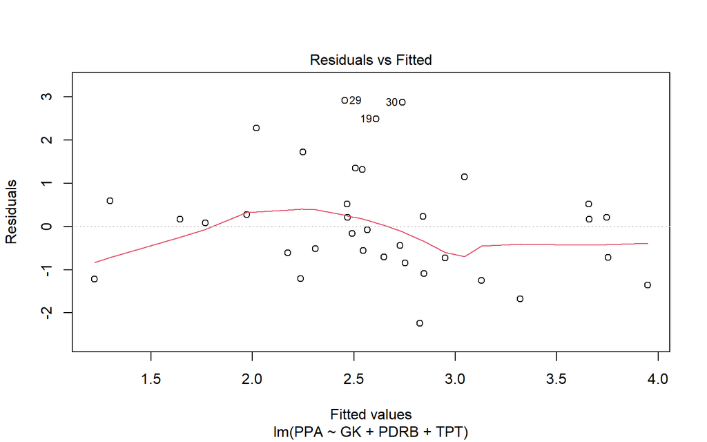

```r
plot(model2,1)
```

### Plot Sisaan vs Urutan

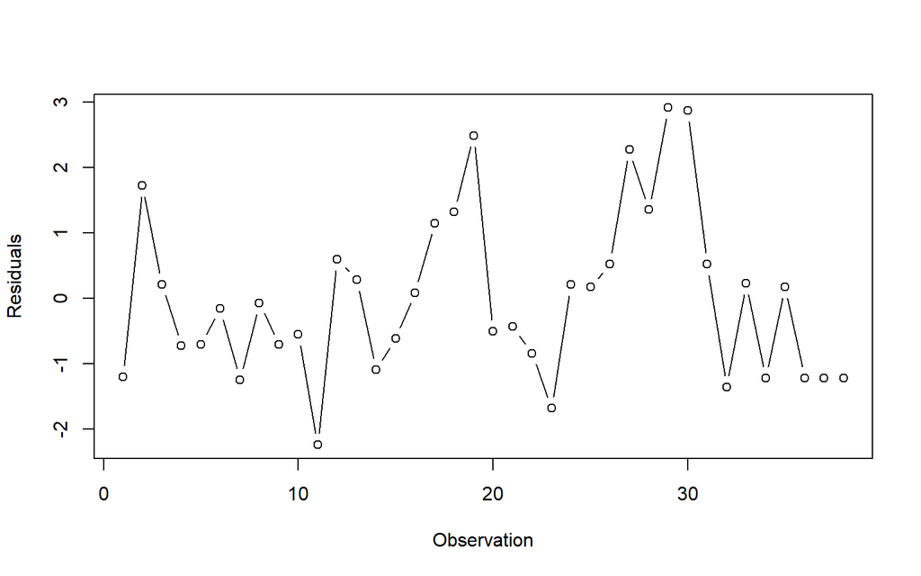

```r
plot(x = 1:dim(dt)[1],
     y = model2$residuals,
     type = 'b',
     ylab = "Residuals",
     xlab = "Observation")
```

### QQ plot

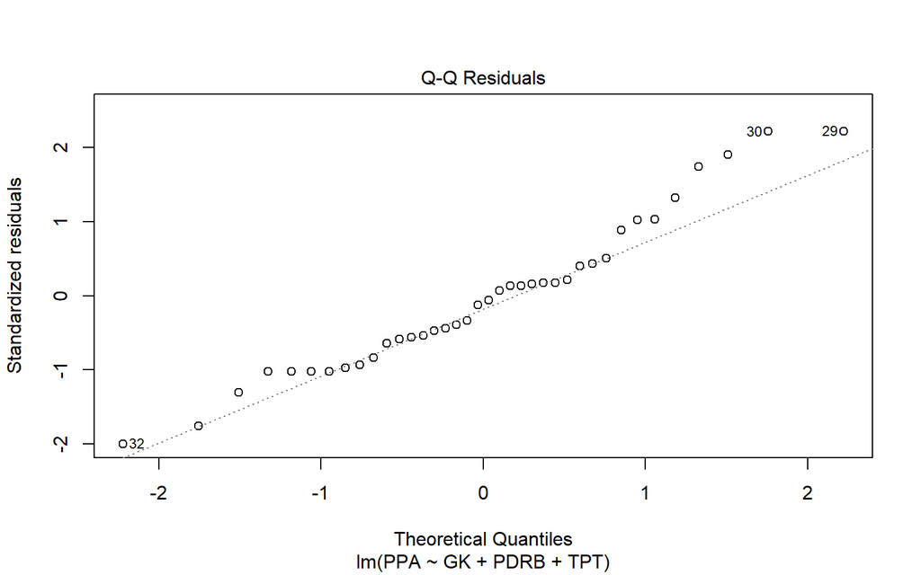

```r
plot(model2,2)
```

Sebagian besar amatan mengikuti garis kuantil teoritis, namun terdapat beberapa amatan di bagian ekor (amatan 29, 30, dan 32) yang menyimpang, sehingga sisaan diduga mendekati normal meskipun perlu dikonfirmasi dengan uji formal.

## Uji Formal

### Nilai harapan sisaan sama dengan nol

```r
t.test(model2$residuals,mu = 0,conf.level = 0.95)
```

```
##
##  One Sample t-test
##
## data:  model2$residuals
## t = -6.694e-17, df = 37, p-value = 1
## alternative hypothesis: true mean is not equal to 0
## 95 percent confidence interval:
##  -0.4200617  0.4200617
## sample estimates:
##     mean of x
## -1.387779e-17
```

Nilai p pada uji t sama dengan 1 yang lebih besar dari alpha 5%, sehingga dinyatakan asumsi nilai harapan sisaan sama dengan nol terpenuhi.

### Ragam sisaan homogen

```r
bptest(model2)
```

```
##
##  studentized Breusch-Pagan test
##
## data:  model2
## BP = 1.8264, df = 3, p-value = 0.6092
```

Nilai p pada uji breusch pagan sama dengan 0.6092 yang lebih besar dari alpha 5%, sehingga dinyatakan asumsi ragam sisaan homogen terpenuhi.

### Sisaan saling bebas

```r
dwtest(model2)
```

```
##
##  Durbin-Watson test
##
## data:  model2
## DW = 1.1359, p-value = 0.001526
## alternative hypothesis: true autocorrelation is greater than 0
```

Nilai p pada uji durbin watson sama dengan 0.0015 yang lebih kecil dari alpha 5%, sehingga dinyatakan asumsi sisaan saling bebas tidak terpenuhi.

### Normalitas Sisaan

```r
shapiro.test(model2$residuals)
```

```
##
##  Shapiro-Wilk normality test
##
## data:  model2$residuals
## W = 0.93713, p-value = 0.03384
```

Nilai p pada uji shapiro wilk sama dengan 0.0338 yang lebih kecil dari alpha 5%, sehingga dinyatakan asumsi normalitas sisaan tidak terpenuhi.

# Pemeriksaan Amatan Tidak Biasa

```r
#fungsi
ri_stud <- rstudent(model2)
ri_stan <- rstandard(model2)
hii_fungsi <- hatvalues(model2)

#manual
X <- model.matrix(model2)
X_inv_xt <- X %*% solve(t(X) %*% X) %*% t(X)
hii_manual <- diag(X_inv_xt)
anova_model <- anova(model2)
s <- sqrt(anova_model["Residuals", "Mean Sq"])
ei <- model2$residuals
ri_manual <- ei/(s*sqrt(1-hii_manual))

nilai <- data.frame(ri_stud, ri_stan, ri_manual, hii_fungsi, hii_manual)
nilai
```

```
##        ri_stud     ri_stan   ri_manual hii_fungsi hii_manual
## 1  -0.93378020 -0.93554364 -0.93554364 0.06160608 0.06160608
## 2   1.34374779  1.32810465  1.32810465 0.05572292 0.05572292
## 3   0.16017712  0.16252277  0.16252277 0.05342307 0.05342307
## 4  -0.55592214 -0.56165847 -0.56165847 0.04903333 0.04903333
## 5  -0.53330688 -0.53900919 -0.53900919 0.02975894 0.02975894
## 6  -0.12118916 -0.12298429 -0.12298429 0.02685348 0.02685348
## 7  -0.96958825 -0.97044346 -0.97044346 0.06637323 0.06637323
## 8  -0.05675847 -0.05760922 -0.05760922 0.02726582 0.02726582
## 9  -0.58020578 -0.58595006 -0.58595006 0.16482235 0.16482235
## 10 -0.43027373 -0.43552440 -0.43552440 0.08009721 0.08009721
## 11 -1.81278187 -1.75474654 -1.75474654 0.07907576 0.07907576
## 12  0.49979044  0.50539734  0.50539734 0.22612036 0.22612036
## 13  0.21225724  0.21530233  0.21530233 0.05850938 0.05850938
## 14 -0.83183635 -0.83563047 -0.83563047 0.03473331 0.03473331
```

[output cut: 24 more lines]

## Pencilan

```r
for (i in 1:dim(nilai)[1]){
  absri <- abs(nilai[,2])
  pencilan <- which(absri > 2)
}
pencilan
```

```
## [1] 29 30 32
```

Amatan ke-29, 30, dan 32 terdeteksi sebagai pencilan

## Leverage

```r
n <- dim(dt)[1]
p <- length(model2$coefficients)

for (i in 1:dim(nilai)[1]){
  cutoff <- 2*p/n
  titik_leverage <- which(hii_fungsi > cutoff)
}
titik_leverage
```

```
## 12 32
## 12 32
```

Amatan ke-12 dan 32 terdeteksi sebagai titik leverage

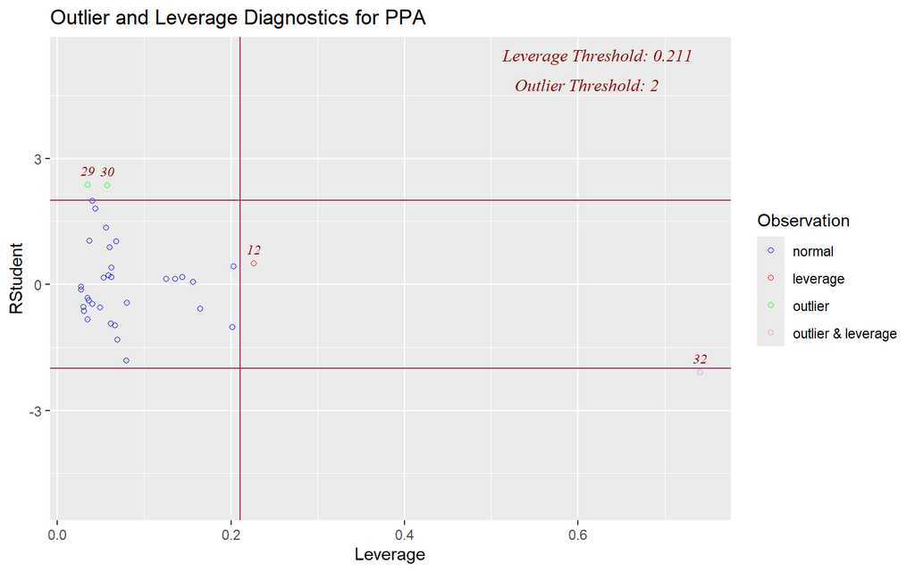

```r
ols_plot_resid_lev(model2)
```

Plot yang terbentuk dari fungsi `ols_plot_resid_lev()` menyatakan bahwa amatan ke-29 dan 30 juga termasuk sebagai pencilan/outlier serta amatan ke-12 juga termasuk leverage. Hal ini dikarenakan perbedaan rumusan yang dipakai pada `rstandard()` dan `rstudent()`.

## Amatan Berpengaruh

### Jarak Cook

```r
di <- cooks.distance(model2)
f <- qf(0.05,p,n-p, lower.tail = F)
data.frame(di, di>f)
```

```
##              di di...f
## 1  1.436503e-02  FALSE
## 2  2.602190e-02  FALSE
## 3  3.726845e-04  FALSE
## 4  4.066406e-03  FALSE
## 5  2.227769e-03  FALSE
## 6  1.043426e-04  FALSE
## 7  1.673787e-02  FALSE
## 8  2.325672e-05  FALSE
## 9  1.693942e-02  FALSE
## 10 4.128958e-03  FALSE
## 11 6.609799e-02  FALSE
## 12 1.865830e-02  FALSE
## 13 7.201898e-04  FALSE
## 14 6.281558e-03  FALSE
```

[output cut: 24 more lines]

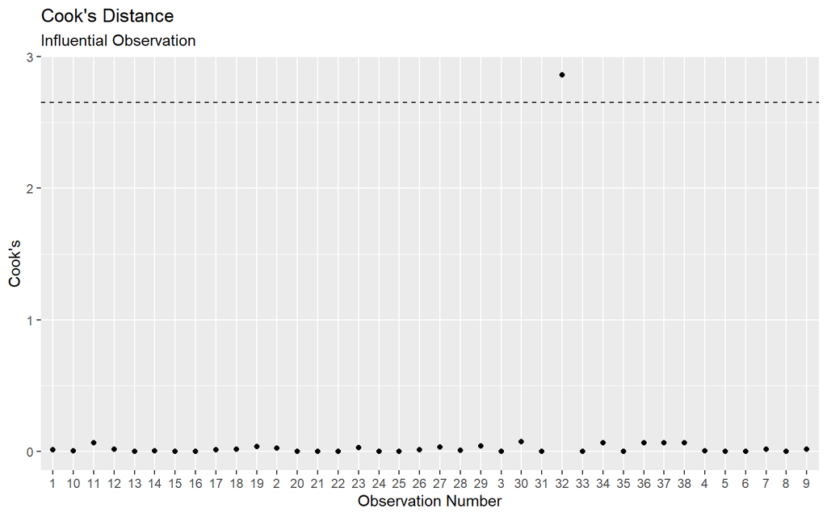

```r
cooks_crit = f
model_cooks <- cooks.distance(model2)
df <- data.frame(obs = names(model_cooks),
                 cooks = model_cooks)
ggplot(df, aes(y = cooks, x = obs)) +
  geom_point() +
  geom_hline(yintercept = cooks_crit, linetype="dashed") +
  labs(title = "Cook's Distance",
       subtitle = "Influential Observation ",
       x = "Observation Number",
       y = "Cook's")
```

Pemeriksaan amatan berpengaruh dengan jarak cook dihasilkan nilai ke-32 termasuk nilai yang melebihi ambang batas.

### DFBETAS

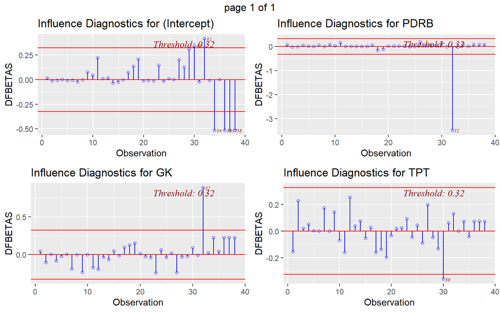

```r
ols_plot_dfbetas(model2)
```

Hasil DFBETAS akan menunjukkan pengaruh observasi terhadap setiap koefisien regresi, sehingga ada output untuk setiap parameter regresi. DFBETAS mengukur seberapa besar koefisien regresi berubah jika suatu observasi dihapus dari model.

### DFFITS

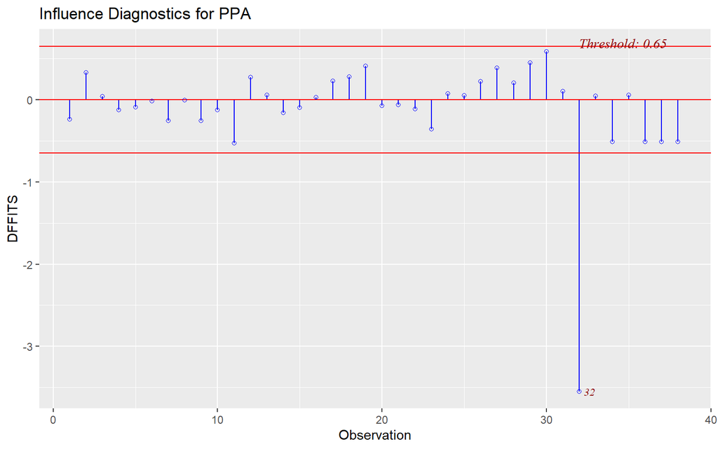

```r
ols_plot_dffits(model2)
```

Hasil DFFITS menunjukkan pengaruh observasi terhadap nilai prediksi Y, sehingga hanya menghasilkan satu output. DFFITS mengukur seberapa besar nilai prediksi $\hat{Y}_i$ berubah jika suatu observasi dihapus dari model, sehingga lebih tepat digunakan jika ingin melihat pengaruh observasi terhadap hasil model secara keseluruhan.

```r
DFFITSi <- dffits(model2)

amatan_berpengaruh <- vector("list", dim(nilai)[1])
for (i in 1:dim(nilai)[1]) {
  cutoff <- 2 * sqrt((p / n))
  amatan_berpengaruh[[i]] <- which(abs(DFFITSi) > cutoff)
}
berpengaruh <- unlist(amatan_berpengaruh)
amatan_berpengaruh <- sort(unique(berpengaruh))
amatan_berpengaruh
```

```
## [1] 32
```

Amatan ke-32 termasuk amatan berpengaruh sehingga sangat riskan jika disisihkan. Perlu ditelusuri lebih lanjut

# Pemodelan Penyisihan Amatan

```r
dt1 <- dt %>% slice(-12)
model3 <- lm(PPA ~ GK + PDRB + TPT, dt1)

dt2 <- dt %>% slice(-29)
model4 <- lm(PPA ~ GK + PDRB + TPT, dt2)

dt3 <- dt %>% slice(-30)
model5 <- lm(PPA ~ GK + PDRB + TPT, dt3)

dt4 <- dt %>% slice(-32)
model6 <- lm(PPA ~ GK + PDRB + TPT, dt3)

dt5 <- dt %>% slice(-c(12, 29))
model7 <- lm(PPA ~ GK + PDRB + TPT, dt4)

dt6 <- dt %>% slice(-c(12, 30))
model8 <- lm(PPA ~ GK + PDRB + TPT, dt5)

dt7 <- dt %>% slice(-c(12, 32))
model9 <- lm(PPA ~ GK + PDRB + TPT, dt5)

dt8 <- dt %>% slice(-c(29, 30))
model10 <- lm(PPA ~ GK + PDRB + TPT, dt6)

dt9 <- dt %>% slice(-c(29, 32))
model11 <- lm(PPA ~ GK + PDRB + TPT, dt6)

dt10 <- dt %>% slice(-c(30, 32))
model12 <- lm(PPA ~ GK + PDRB + TPT, dt6)

dt11 <- dt %>% slice(-c(12, 29, 30))
model13 <- lm(PPA ~ GK + PDRB + TPT, dt7)

dt12 <- dt %>% slice(-c(12, 29, 32))
model14 <- lm(PPA ~ GK + PDRB + TPT, dt7)

dt13 <- dt %>% slice(-c(12, 30, 32))
model15 <- lm(PPA ~ GK + PDRB + TPT, dt7)

dt14 <- dt %>% slice(-c(29, 30, 32))
model16 <- lm(PPA ~ GK + PDRB + TPT, dt7)
```

```r
get_metrics <- function(model) {
  adj_r2 <- summary(model)$adj.r.squared
  sse <- sum(model$residuals^2)
  return(c(adj_r2, sse))
}

model_metrics <- data.frame(
  Model = c("Model 2", "Model 3", "Model 4", "Model 5", "Model 6",
            "Model 7", "Model 8", "Model 9", "Model 10", "Model 11", "Model 12", "Model 13", "Model 14", "Model 15", "Model 16"),
  Adjusted_R2 = sapply(list(model2, model3, model4, model5,
                            model6, model7, model8, model9, model10, model11, model12, model13, model14, model15, model16),
                       function(m) get_metrics(m)[1]),
  SSE = sapply(list(model2, model3, model4, model5,
                    model6, model7, model8, model9, model10, model11, model12, model13, model14, model15, model16),
               function(m) get_metrics(m)[2])
)

print(model_metrics)
```

```
##       Model Adjusted_R2      SSE
## 1   Model 2   0.1831492 60.42965
## 2   Model 3   0.1831441 59.97567
## 3   Model 4   0.2195355 51.63263
## 4   Model 5   0.2026944 51.67708
## 5   Model 6   0.2026944 51.67708
## 6   Model 7   0.2774918 53.31606
## 7   Model 8   0.2212426 51.16124
## 8   Model 9   0.2212426 51.16124
## 9  Model 10   0.2017976 51.37594
## 10 Model 11   0.2017976 51.37594
## 11 Model 12   0.2017976 51.37594
## 12 Model 13   0.2752028 53.07643
## 13 Model 14   0.2752028 53.07643
## 14 Model 15   0.2752028 53.07643
## 15 Model 16   0.2752028 53.07643
```

```r
stargazer(model2, model4, model9, type = "text", font.size = "small",
          report = "vc*p")
```

```
##
## ==================================================================================
##                                          Dependent variable:
##                     --------------------------------------------------------------
##                                                  PPA
##                             (1)                  (2)                  (3)
## ----------------------------------------------------------------------------------
## GK                       0.00000**            0.00000***           0.00000***
##                          p = 0.013            p = 0.008            p = 0.009
##
## PDRB                       0.087                0.084                0.084
##                          p = 0.242            p = 0.227            p = 0.234
##
## TPT                       -0.325*              -0.304*              -0.347*
##                          p = 0.060            p = 0.061            p = 0.059
##
## Constant                  1.221**               1.048*               1.041*
##                          p = 0.050            p = 0.074            p = 0.079
##
## ----------------------------------------------------------------------------------
## Observations                 38                   37                   36
## R2                         0.249                0.285                0.288
## Adjusted R2                0.183                0.220                0.221
## Residual Std. Error   1.333 (df = 34)      1.251 (df = 33)      1.264 (df = 32)
## F Statistic         3.765** (df = 3; 34) 4.375** (df = 3; 33) 4.314** (df = 3; 32)
## ==================================================================================
## Note:                                                  *p<0.1; **p<0.05; ***p<0.01
```